# Bootstrap Confidence Interval for a Difference in Means

## Confidence Intervals

- Hypothesis tests provide “yes” or “no” answers.
- Confidence intervals provide “how much” answers.
  - In this scenario, we are instead interested in estimating the unknown value of a population parameter.
- For this example, a confidence interval can be used to the range of values that seem plausible for the difference in the mean exam scores (\(\mu_A - \mu_B\)).

## Assumptions Behind a Bootstrap

- Here, we are assuming that the scores earned on the exam are representative of the population of all scores students may have earned on these exams.
- We want to estimate what scores other students may have earned taking exam A and exam B.
- The process of bootstrapping is applied to *each* group separately.
  - This assumes the exam scores for each group are representative of all possible scores students would have earned on each exam.

## Creating a Bootstrap Distribution

- For every resample, we calculate the difference in means  
  (\(\bar{x}_A - \bar{x}_B\)).

```r
boot <- classdata %>%
  specify(m1 ~ exam) %>%
  generate(reps = 2000, type = "bootstrap") %>%
  calculate(stat = "diff in means", order = c("a", "b"))
```

## Visualizing the Bootstrap Distribution

- A distribution of these bootstrap statistics gives us an idea of the variability we’d expect in repeated samples from the population.

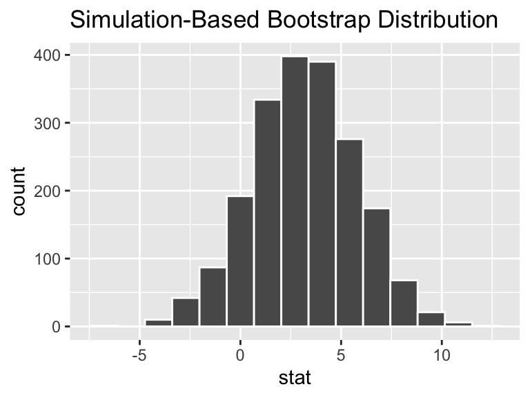

```r
boot %>%
  visualise()
```

## Calculating a Confidence Interval

[figure not shown]

```r
boot %>%
  get_confidence_interval(level = 0.95)
```

```
## # A tibble: 1 x 2
##   lower_ci upper_ci
##      <dbl>    <dbl>
## 1    -2.12     8.20
```

## Interpretting a Confidence Interval

When interpreting the confidence interval we need to remember what the population parameter we are estimating is.

- Here, we are interested in the difference in the mean score on exam A and exam B for all of the students.